# Microbiome Feature Analysis

LaShanda Williams, PhD

December 6, 2025

## Research Summary

This analysis applies compositional data–aware statistical methods to identify key bacterial features differentiating clinical vaginal conditions, using both community-wide and taxon-specific approaches. Raw OTU count data were log-centered (CLR) transformed to mitigate compositional bias, and alpha diversity indices were computed to assess ecological structure. Multivariate differences between clinical groups (BV, BVVC, and Healthy) were tested using PERMANOVA, while dispersion differences were evaluated via BETADISPER to ensure that observed separations reflect true centroid shifts rather than increased variability.

## 1. Data Processing and Feature Engineering

### 1.1 Load Libraries and Raw Data

```r
library(readxl)
library(tidyverse)
library(ALDEx2)
library(vegan)
library(rstatix)
library(ggpubr)
library(stats)
```

```r
otu_file <- "../../01_data/raw/zmeh_a_11816030_sm0001.xlsx"
meta_file <- "../../01_data/raw/zmeh_a_11816030_sm0002.xlsx"
```

```r
df_otu <- read_excel(otu_file, col_names = TRUE, skip = 1)
df_meta <- read_excel(meta_file, col_names = TRUE, skip = 1)

names(df_otu)[1] <- "OTU_ID"
names(df_meta)[1] <- "Sample_ID"
```

```r
otu_counts_final <- df_otu %>%
    column_to_rownames("OTU_ID") %>%
    mutate(across(everything(), as.numeric)) %>%
    mutate(across(everything(), ~replace_na(., 0))) %>%
    mutate(across(everything(), as.integer))
STATUS_PATTERN <- "[a-z]+$"

metadata_aligned <- df_meta %>%
    filter(time == 0) %>%
    mutate(Status_Code = str_extract(Sample_ID, pattern = STATUS_PATTERN)) %>%
    mutate(Status_Code = tolower(Status_Code)) %>%
    mutate(Sample_ID = trimws(Sample_ID)) %>%
    column_to_rownames("Sample_ID")
```

```r
common_samples <- intersect(colnames(otu_counts_final), rownames(metadata_aligned))
otu_counts_final <- otu_counts_final[, common_samples]
metadata_aligned <- metadata_aligned[common_samples, ]
```

### 1.2 Data Filtering and Preparation

```r
min_prevalence <- 5
min_count <- 10

otus_to_keep <- rowSums(otu_counts_final > 0) >= min_prevalence &
                rowSums(otu_counts_final) >= min_count

otu_counts_final <- otu_counts_final[otus_to_keep, ]

# --- Remove zero-sum samples ---
zero_samples <- which(colSums(otu_counts_final) == 0)
if (length(zero_samples) > 0) {
    otu_counts_final <- otu_counts_final[, -zero_samples]
    metadata_aligned <- metadata_aligned[colnames(otu_counts_final), ]
}

cat("Final Aligned Samples:", ncol(otu_counts_final), "\n")
```

```
## Final Aligned Samples: 164
```

```r
cat("Final Features Remaining:", nrow(otu_counts_final), "\n")
```

```
## Final Features Remaining: 77
```

### 1.3 Centered Log-Ratio (CLR) Transformation

```r
condition_vector <- metadata_aligned[colnames(otu_counts_final), "Status_Code"]

clr_results <- aldex.clr(
    reads = otu_counts_final,
    conds = as.character(condition_vector),
    mc.samples = 128,
    denom = "all",
    verbose = FALSE,
    useMC = TRUE
)
```

```
## conditions vector supplied
```

```
## multicore environment is is OK -- using the BiocParallel package
```

```
## computing center with all features
```

```r
clr_mc <- slot(clr_results, "analysisData")

if (length(clr_mc) < 1) stop("ALDEx2 returned zero CLR Monte Carlo samples.")

num_samples <- length(clr_mc)
num_features <- nrow(clr_mc[[1]])
clr_feature_matrix <- matrix(NA, nrow = num_samples, ncol = num_features)

sample_ids <- names(clr_mc)
rownames(clr_feature_matrix) <- sample_ids

for (i in seq_along(clr_mc)) {
  clr_feature_matrix[i, ] <- rowMeans(clr_mc[[i]])
}

colnames(clr_feature_matrix) <- paste0("CLR_", rownames(clr_mc[[1]]))
clr_feature_matrix <- as.data.frame(clr_feature_matrix)
```

### 1.4 Alpha Diversity Calculation

```r
otu_samples_in_rows <- as.data.frame(t(otu_counts_final))

alpha_diversity <- data.frame(
    SampleID = rownames(otu_samples_in_rows),
    Shannon_Index = diversity(otu_samples_in_rows, index = "shannon"),
    Observed_Richness = specnumber(otu_samples_in_rows)
)

rownames(alpha_diversity) <- alpha_diversity$SampleID
alpha_diversity$SampleID <- NULL
```

### 1.5 Dataset Finalization

```r
metadata_to_join <- metadata_aligned %>%
  rownames_to_column("SampleID")

final_features_temp <- clr_feature_matrix %>%
  rownames_to_column("SampleID") %>%
  inner_join(alpha_diversity %>% rownames_to_column("SampleID"), by = "SampleID")

df_full_features_with_status <- final_features_temp %>%
    inner_join(metadata_to_join, by = "SampleID") %>%
    column_to_rownames("SampleID")

write.csv(df_full_features_with_status,
          file = "../../01_data/processed/final_ml_feature_matrix.csv",
          row.names = TRUE)
```

## 2. Multivariate Feature Validation

### 2.1 Global Separation (PCA, PERMANOVA, BETADISPER)

First, PCA was performed

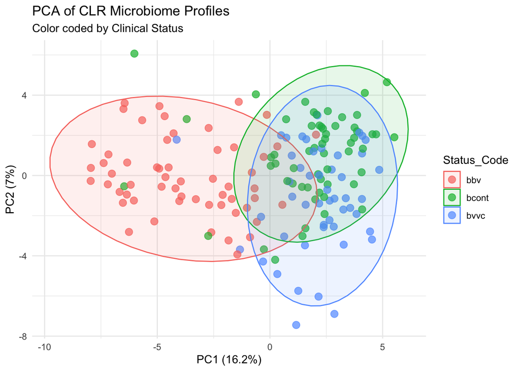

```r
df_full <- df_full_features_with_status
clr_cols <- grep("^CLR_", names(df_full), value = TRUE)
df_pca_input <- df_full[, clr_cols]

pca_result <- prcomp(df_pca_input, scale. = TRUE)

pca_scores <- as.data.frame(pca_result$x) %>%
  dplyr::select(PC1, PC2) %>%
  mutate(Status_Code = df_full$Status_Code)

variance_explained <- summary(pca_result)$importance[2, 1:2]
pc1_var <- paste0("PC1 (", round(variance_explained[1] * 100, 1), "%)")
pc2_var <- paste0("PC2 (", round(variance_explained[2] * 100, 1), "%)")

p1 <- ggplot(pca_scores, aes(x = PC1, y = PC2, color = Status_Code)) +
  geom_point(size = 3, alpha = 0.7) +
  stat_ellipse(geom = "polygon", alpha = 0.1, aes(fill = Status_Code)) +
  labs(title = "PCA of CLR Microbiome Profiles",
       subtitle = "Color coded by Clinical Status",
       x = pc1_var,
       y = pc2_var) +
  theme_minimal()
print(p1)
```

```r
ggsave("~/Vaginal_Microbiome_ML_Classifier/03_results/figures/pca_plot.png", plot = p1, width = 7, height = 5)
```

PERMANOVA using CLR-transformed Aitchison distances demonstrated highly significant differences in microbiome composition between clinical groups. * Microbial community structure differed significantly between at least two clinical groups (p = 0.001).  
* ~13.5% of variation in global microbiome composition is explained by clinical classification (R² = 0.1348).

```r
clr_cols <- grep("^CLR_", names(df_full), value = TRUE)
df_clr_input <- df_full[, clr_cols]

dist_matrix <- dist(df_clr_input, method = "euclidean")

permanova_result <- adonis2(dist_matrix ~ Status_Code, data = df_full, permutations = 999)
print(permanova_result)
```

```
## Permutation test for adonis under reduced model
## Permutation: free
## Number of permutations: 999
##
## adonis2(formula = dist_matrix ~ Status_Code, data = df_full, permutations = 999)
##           Df SumOfSqs      R2     F Pr(>F)
## Model      2     8796 0.13478 12.54  0.001 ***
## Residual 161    56464 0.86522
## Total    163    65259 1.00000
## ---
## Signif. codes:  0 '***' 0.001 '**' 0.01 '*' 0.05 '.' 0.1 ' ' 1
```

A BETADISPER test was performed to ensure that PERMANOVA differences reflect true centroid separation and are not artifacts of differing dispersion. - There is significant difference in dispersion between groups (p = 0.003).  
- BV samples exhibited substantially greater dispersion compared with healthy or VVC samples, consistent with the known ecological instability of BV-associated microbiota.

```r
dispersion <- betadisper(dist_matrix, df_full$Status_Code)
betadisper_result <- permutest(dispersion, permutations = 999)
print(betadisper_result)
```

```
##
## Permutation test for homogeneity of multivariate dispersions
## Permutation: free
## Number of permutations: 999
##
## Response: Distances
##            Df  Sum Sq Mean Sq      F N.Perm Pr(>F)
## Groups      2   90.89  45.444 6.0969    999  0.003 **
## Residuals 161 1200.02   7.454
## ---
## Signif. codes:  0 '***' 0.001 '**' 0.01 '*' 0.05 '.' 0.1 ' ' 1
```

### 2.2 Post-Hoc Pairwise PERMANOVA

Pairwise PERMANOVA revealed that BV differed substantially from both healthy controls (R² = 0.134) and VVC (R² = 0.125), reflecting the well-characterized, high-diversity dysbiosis associated with BV. In contrast, VVC and healthy microbiomes were much more similar (R² = 0.041), consistent with prior findings that VVC typically retains a Lactobacillus-dominant community structure. All comparisons remained significant after FDR correction (p = 0.001), indicating robust between-group differences driven primarily by BV status.

```r
dist_matrix <- dist(df_full[, clr_cols], method = "euclidean")
groups <- df_full$Status_Code

pairwise_permanova_results <- data.frame()
group_levels <- levels(factor(groups))

for (i in 1:(length(group_levels) - 1)) {
    for (j in (i + 1):length(group_levels)) {
        group1 <- group_levels[i]
        group2 <- group_levels[j]

        # Subset data for the pair
        subset_samples <- df_full %>% filter(Status_Code %in% c(group1, group2))
        subset_dist <- dist(subset_samples[, clr_cols], method = "euclidean")

        # Run PERMANOVA on the subset
        res <- adonis2(subset_dist ~ Status_Code, data = subset_samples, permutations = 999)

        # Store results
        pairwise_permanova_results <- rbind(pairwise_permanova_results, data.frame(
            Comparison = paste(group1, "vs", group2),
            R2 = res$R2[1],
            P_Value = res$`Pr(>F)`[1]
        ))
    }
}

# Apply FDR correction (Benjamini-Hochberg)
pairwise_permanova_results <- pairwise_permanova_results %>%
    mutate(FDR_P_Value = p.adjust(P_Value, method = "fdr"))

print(pairwise_permanova_results)
```

```
##      Comparison         R2 P_Value FDR_P_Value
## 1  bbv vs bcont 0.13433218   0.001       0.001
## 2   bbv vs bvvc 0.12472077   0.001       0.001
## 3 bcont vs bvvc 0.04121446   0.001       0.001
```

## 3. Univariate Biomarker Validation

### 3.1 Kruskal-Wallis Test

A Kruskal-Wallis test was performed to identify statistically significant differences in the relative abundance of the top 5 biomarkers in the dataset: CLR_1, CLR_14, CLR_17, CLR_3, and CLR_43. Across the top 5 biomarkers, there is a statistical significant result (p < 2.2e-16) indicating at least one group has a different microbial abundance compared to the others. Post-Hoc tests will be conducted next to determine which groups differ across the selected taxa.

```r
top_biomarkers <- c("CLR_1", "CLR_14", "CLR_17", "CLR_3", "CLR_43")

kw_results <- df_full %>%
    select(Status_Code, all_of(top_biomarkers)) %>%
    pivot_longer(-Status_Code, names_to = "Feature", values_to = "Value") %>%
    group_by(Feature) %>%
    kruskal.test(Value ~ Status_Code)
print(kw_results)
```

[output not shown]

### 3.2 Post-Hoc Dunn’s Test

```r
dunn_test_results <- df_full %>%
    select(Status_Code, all_of(top_biomarkers)) %>%
    pivot_longer(-Status_Code, names_to = "Feature", values_to = "Value") %>%
    group_by(Feature) %>%
    dunn_test(Value ~ Status_Code, p.adjust.method = "fdr")

print(dunn_test_results)
```

```
## # A tibble: 15 × 10
##    Feature .y.   group1 group2    n1    n2 statistic        p    p.adj
##  * <chr>   <chr> <chr>  <chr>  <int> <int>     <dbl>    <dbl>    <dbl>
##  1 CLR_1   Value bbv    bcont     57    58    8.88   6.75e-19 2.02e-18
##  2 CLR_1   Value bbv    bvvc      57    49    8.21   2.24e-16 3.35e-16
##  3 CLR_1   Value bcont  bvvc      58    49   -0.293  7.70e- 1 7.70e- 1
##  4 CLR_14  Value bbv    bcont     57    58   -7.70   1.40e-14 4.21e-14
##  5 CLR_14  Value bbv    bvvc      57    49   -4.26   2.03e- 5 3.04e- 5
##  6 CLR_14  Value bcont  bvvc      58    49    3.12   1.82e- 3 1.82e- 3
##  7 CLR_17  Value bbv    bcont     57    58    8.63   6.06e-18 1.82e-17
##  8 CLR_17  Value bbv    bvvc      57    49    7.33   2.23e-13 3.35e-13
##  9 CLR_17  Value bcont  bvvc      58    49   -0.933  3.51e- 1 3.51e- 1
## 10 CLR_3   Value bbv    bcont     57    58    7.55   4.47e-14 6.71e-14
## 11 CLR_3   Value bbv    bvvc      57    49    7.74   1.01e-14 3.02e-14
## 12 CLR_3   Value bcont  bvvc      58    49    0.516  6.06e- 1 6.06e- 1
## 13 CLR_43  Value bbv    bcont     57    58    8.29   1.10e-16 3.29e-16
## 14 CLR_43  Value bbv    bvvc      57    49    7.96   1.75e-15 2.63e-15
## 15 CLR_43  Value bcont  bvvc      58    49    0.0174 9.86e- 1 9.86e- 1
## # ℹ 1 more variable: p.adj.signif <chr>
```

### 3.3 Visualization of Biomarker Distributions

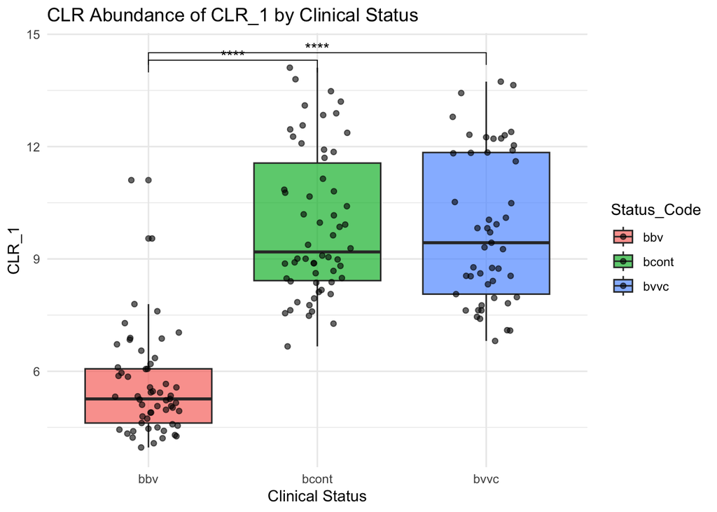

```r
plot_clr_features <- function(data, feature_name, dunn_results) {

  dunn_feature <- dunn_results %>%
    filter(Feature == feature_name) %>%
    arrange(p.adj) %>%
    mutate(
      y.position = max(data[[feature_name]], na.rm = TRUE) + 0.2 * row_number()
    )

  p <- ggplot(data, aes(x = Status_Code, y = !!sym(feature_name), fill = Status_Code)) +
    geom_boxplot(alpha = 0.7) +
    geom_jitter(width = 0.2, size = 1.5, alpha = 0.6) +
    labs(
      title = paste("CLR Abundance of", feature_name, "by Clinical Status"),
      x = "Clinical Status",
      y = feature_name
    ) +
    theme_minimal() +
    stat_pvalue_manual(
      dunn_feature,
      hide.ns = TRUE,
      label = "p.adj.signif"
    )

  return(p)
}

clr1_plot <- plot_clr_features(df_full, "CLR_1", dunn_test_results)
print(clr1_plot)
```

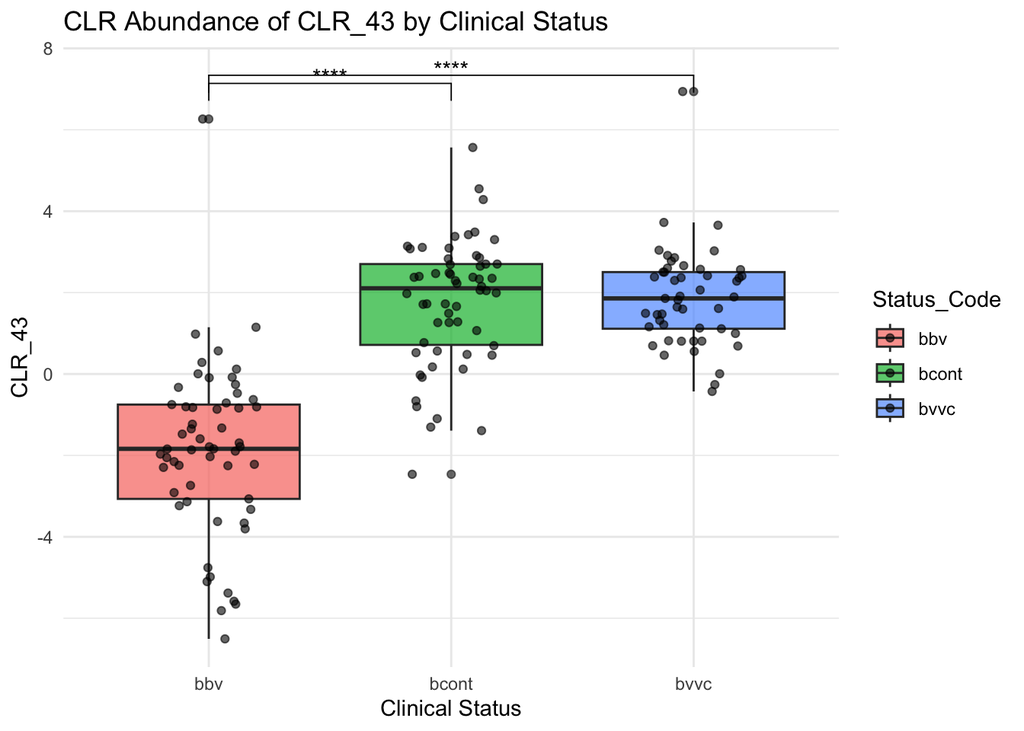

```r
ggsave("../../03_results/figures/clr1_dunn_test_results.png", plot = clr1_plot)
clr43_plot <- plot_clr_features(df_full, "CLR_43", dunn_test_results)
print(clr43_plot)
```

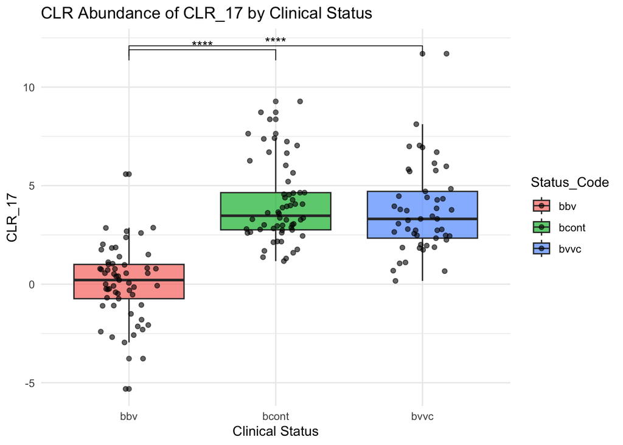

```r
ggsave("../../03_results/figures/clr43_dunn_test_results.png", plot = clr43_plot)
clr17_plot <- plot_clr_features(df_full, "CLR_17", dunn_test_results)
print(clr17_plot)
```

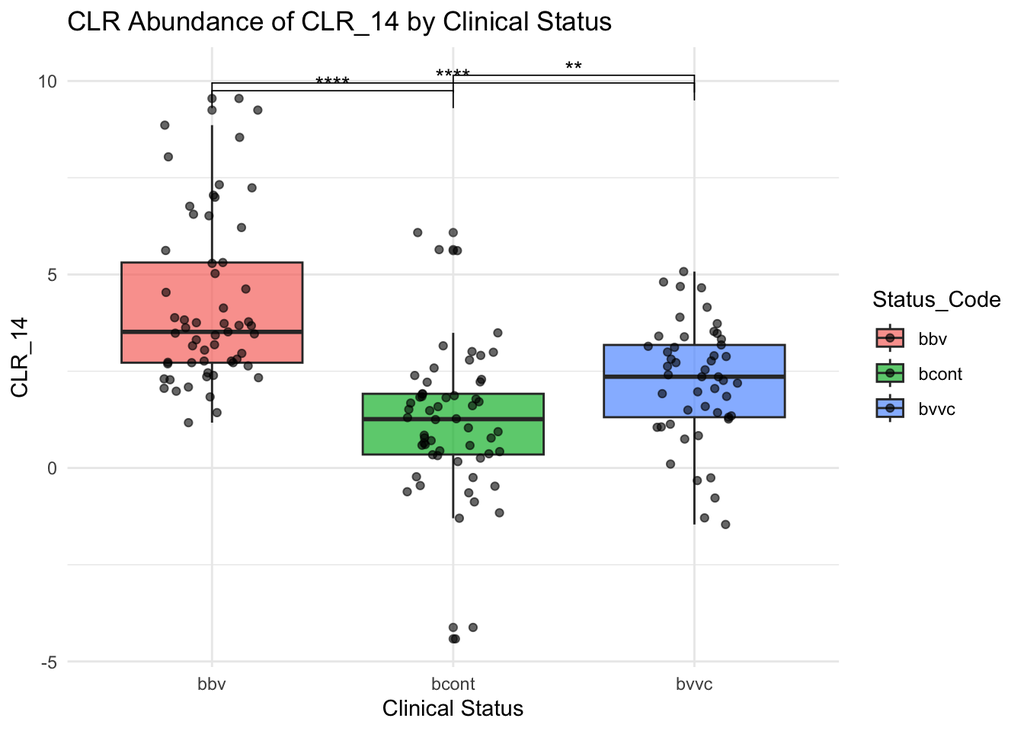

```r
ggsave("../../03_results/figures/clr17_dunn_test_results.png", plot = clr17_plot)
clr14_plot <- plot_clr_features(df_full, "CLR_14", dunn_test_results)
print(clr14_plot)
```

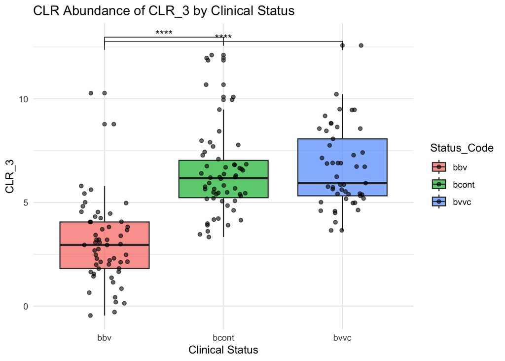

```r
ggsave("../../03_results/figures/clr14_dunn_test_results.png", plot = clr14_plot)
clr3_plot <- plot_clr_features(df_full, "CLR_3", dunn_test_results)
print(clr3_plot)
```

```r
ggsave("../../03_results/figures/clr3_dunn_test_results.png", plot = clr3_plot)
```

### 3.4 Pairwise Mann-Whitney U (Wilcoxon Rank-Sum) Tests (FDR Corrected)

```r
wilcox_results <- df_full %>%
    select(Status_Code, all_of(top_biomarkers)) %>%
    pivot_longer(-Status_Code, names_to = "Feature", values_to = "Value") %>%
    group_by(Feature) %>%
    wilcox_test(Value ~ Status_Code, p.adjust.method = "fdr")

print(wilcox_results)
```

```
## # A tibble: 15 × 10
##    Feature .y.   group1 group2    n1    n2 statistic        p    p.adj
##  * <chr>   <chr> <chr>  <chr>  <int> <int>     <dbl>    <dbl>    <dbl>
##  1 CLR_1   Value bbv    bcont     57    58        92 2.57e-18 7.71e-18
##  2 CLR_1   Value bbv    bvvc      57    49        79 7.10e-17 1.06e-16
##  3 CLR_1   Value bcont  bvvc      58    49      1492 6.59e- 1 6.59e- 1
##  4 CLR_14  Value bbv    bcont     57    58      2970 1.78e-13 5.34e-13
##  5 CLR_14  Value bbv    bvvc      57    49      2125 3.97e- 6 5.96e- 6
##  6 CLR_14  Value bcont  bvvc      58    49       866 5.26e- 4 5.26e- 4
##  7 CLR_17  Value bbv    bcont     57    58       142 2.93e-17 8.79e-17
##  8 CLR_17  Value bbv    bvvc      57    49       211 5.96e-14 8.94e-14
##  9 CLR_17  Value bcont  bvvc      58    49      1600 2.64e- 1 2.64e- 1
## 10 CLR_3   Value bbv    bcont     57    58       280 1.62e-14 4.86e-14
## 11 CLR_3   Value bbv    bvvc      57    49       203 4.04e-14 6.06e-14
## 12 CLR_3   Value bcont  bvvc      58    49      1313 5.01e- 1 5.01e- 1
## 13 CLR_43  Value bbv    bcont     57    58       222 1.22e-15 1.83e-15
## 14 CLR_43  Value bbv    bvvc      57    49        93 1.5 e-16 4.50e-16
## 15 CLR_43  Value bcont  bvvc      58    49      1468 7.71e- 1 7.71e- 1
## # ℹ 1 more variable: p.adj.signif <chr>
```

## Conclusion

Taken together, the multivariate, univariate, and visualization results all tell a very consistent story about these vaginal microbiome profiles and how they differ across clinical groups.

## 1. Ordination: PCA

- **BBV (red)** samples cluster on one side of PC1 with a broad, diffuse ellipse, reflecting both a different centroid and higher dispersion.
- **BCONT (green)** and **BVVC (blue)** form partially overlapping ellipses on the opposite side of PC1, indicating similar centroids and more compact, Lactobacillus-dominated communities.
- There is clear **separation between BV and non-BV**, but substantial overlap between healthy and VVC.

The PCA thus provides an intuitive geometric picture of the same pattern quantified by PERMANOVA: **BV drives most of the global compositional separation**, while VVC sits much closer to “healthy-like” community states.

## 2. Global community structure: PERMANOVA + dispersion

The overall PERMANOVA on CLR‐transformed profiles shows that **clinical status explains a substantial fraction of the variance in community composition**:

- **R² = 0.135, F = 12.5, p = 0.001** (999 permutations)

In microbial ecology, an R² around 0.13 is a **strong effect**, indicating that BV/healthy/VVC status is a major driver of global microbiome differences rather than just noise.

Pairwise PERMANOVA refines this:

- **BBV vs BCONT:** R² ≈ **0.134**, FDR p = 0.001
- **BBV vs BVVC:** R² ≈ **0.125**, FDR p = 0.001
- **BCONT vs BVVC:** R² ≈ **0.041**, FDR p = 0.001

So:

- BV profiles differ strongly from both healthy controls and VVC (each explaining ~12–13% of variance).
- Healthy controls and VVC differ only **weakly** (~4% of variance), even though the difference is statistically detectable.

The **beta‐dispersion test** confirms that the **within‐group variability** also differs:

- **F = 6.0969, p = 0.003** for multivariate dispersion

BV shows much higher dispersion (more spread around its centroid) than healthy or VVC, consistent with BV being an ecologically unstable, polymicrobial dysbiosis. This means the PERMANOVA signal reflects **both** a shift in average community structure and increased heterogeneity in BV, which is biologically expected rather than artifactual.

## 3. Feature-level differences: Dunn and Wilcoxon tests

Univariate testing with **Dunn’s post-hoc test** and **Wilcoxon rank-sum tests** zooms in from community-level structure to **specific CLR features (candidate biomarkers)**.

Across the top CLR features (CLR_1, CLR_3, CLR_17, CLR_43, CLR_14):

- For **BV vs BCONT** and **BV vs BVVC**, both Dunn and Wilcoxon consistently yield **extremely small FDR-adjusted p-values** (typically **p.adj < 10⁻¹³** and often < 10⁻¹⁶), with large test statistics.
- For **BCONT vs BVVC**, four of the five features show **no significant difference** (p.adj ≫ 0.05, “ns”), and only **CLR_14** shows a more modest, though significant, shift.

The boxplots make these patterns very clear:

- For **CLR_1, CLR_3, CLR_17, CLR_43**, BV samples are shifted strongly away from both healthy and VVC, while **healthy and VVC distributions largely overlap**.
- **CLR_14** shows a gradient (BV highest, VVC intermediate, control lowest), explaining why the control–VVC comparison is significant for this one feature but not the others.

In other words, the **key taxon-level changes are BV-specific**: these biomarkers sharply differentiate BV from the other two groups but do **not** meaningfully discriminate between healthy and VVC. Dunn and Wilcoxon provide convergent evidence for this, using complementary non-parametric frameworks.

## 4. Integrated biological picture

Putting all of this together:

- **BV** is characterized by a **large, global shift** in community structure (PERMANOVA R² ~ 0.13 vs both other groups), **greater beta-dispersion**, and **dramatic shifts in multiple CLR biomarkers**, consistent with a high-diversity, Lactobacillus-depleted dysbiosis.
- **VVC** does **not** show strong bacterial community disruption:
  - It clusters close to controls in PCA.
  - Pairwise PERMANOVA effect size vs controls is small (R² ~ 0.04).
  - Most top biomarkers are indistinguishable between VVC and controls on Dunn and Wilcoxon tests.
- This aligns with the classical observation that **VVC is primarily a fungal disturbance superimposed on an otherwise Lactobacillus-dominated bacterial community**, whereas BV is a genuine bacterial community collapse and re-assembly.

Thus, multivariate (PERMANOVA, PCA, dispersion) and univariate (Dunn, Wilcoxon) analyses are mutually reinforcing and biologically coherent.

## 5. Implications and predictions for downstream classification modelling

Given these patterns, we can make concrete predictions about machine-learning performance:

1. **BV vs non-BV classification (binary) should perform extremely well.**
   - Strong global separation (R² ~ 0.13) and large per-feature shifts suggest **high AUC, accuracy, and recall** for BV.
   - SHAP values for features like CLR_1, CLR_3, CLR_17, CLR_43, and CLR_14 should show large, consistent contributions for identifying BV samples.
2. **Three-class classification (BBV vs BCONT vs BVVC) will mostly struggle at the boundary between BCONT and BVVC.**
   - BV will be classified confidently and correctly most of the time.
   - Misclassifications will predominantly be **healthy ↔︎ VVC**, reflecting their small effect size (R² ~ 0.04) and largely overlapping CLR distributions.